# 12_forecasts_predictions_accepted

**Review**

Hi, my name is Dmitry and I will be reviewing your project.

You can find my comments in colored markdown cells:

If everything is done successfully.

If I have some (optional) suggestions, or questions to think about, or general comments.

If a section requires some corrections. Work can't be accepted with red comments.

Please don't remove my comments, as it will make further review iterations much harder for me.

Feel free to reply to my comments or ask questions using the following template:

For your comments and questions.

First of all, thank you for turning in the project! You did an excellent job! The project is accepted. Good luck on the final sprint! :)

# Forcasts and Predictions Course Project

*Project Description*

The gym chain Model Fitness is developing a customer interaction strategy based on analytical data.

One of the most common problems gyms and other services face is customer churn. How do you know if a customer is no longer with you? You can calculate churn based on people who get rid of their accounts or don't renew their contracts. However, sometimes it's not obvious that a client has left: they may walk out on tiptoes.

For a gym, it makes sense to say a customer has left if they don't come for a month. Of course, it's possible they're in Cancun and will resume their visits when they return, but's that's not a typical case. Usually, if a customer joins, comes a few times, then disappears, they're unlikely to come back.

In order to fight churn, Model Fitness has digitized a number of its customer profiles.

*Tasks*

- Analyze the customer profiles and come up with a customer retention strategy.
  - Learn to predict the probability of churn (for the upcoming month) for each customer
  - Draw up typical user portraits: select the most outstanding groups and describe their main features
  - Analyze the factors that impact churn most
  - Draw basic conclusions and develop recommendations on how to improve customer service:
    - Identify target groups
    - Suggest measures to cut churn
    - Describe any other patterns you see with respect to interaction with customers

*Important things to consider*

*Description of the data*

- file path: /datasets/gym_churn_us.csv
- Model Fitness' csv contains data on chrun for a given month and information on the month preceding it and contains:
  - User data for the preceding month
    - 'gender'
    - 'Near_Location' — whether the user lives or works in the neighborhood where the gym is located
    - 'Partner' — whether the user is an employee of a partner company (the gym has partner companies whose employees get discounts; in those cases the gym stores information on customers' employers)
    - Promo_friends — whether the user originally signed up through a "bring a friend" offer (they used a friend's promo code when paying for their first membership)
    - 'Phone' — whether the user provided their phone number
    - 'Age'
    - 'Lifetime' — the time (in months) since the customer first came to the gym
  - Data from the log of visits and purchases and data on current membership status
    - 'Contract_period' — 1 month, 3 months, 6 months, or 1 year
    - 'Month_to_end_contract' — the months remaining until the contract expires
    - 'Group_visits' — whether the user takes part in group sessions
    - 'Avg_class_frequency_total' — average frequency of visits per week over the customer's lifetime
    - 'Avg_class_frequency_current_month' — average frequency of visits per week over the preceding month
    - 'Avg_additional_charges_total' — the total amount of money spent on other gym services: cafe, athletic goods, cosmetics, massages, etc.

*Instructions for completing the project*

*Step 1. Open the data file and read the general information*

- *Step 1. Conclusion*

*Step 2. Carry out exploratory data analysis (EDA)*

- 2.a Look for missing features
  - 2.a Conclusion
- 2.b Use the describe() method to study the mean values and standard deviation
  - 2.b Conclusion
- 2.c Use the groupby() method to look at the mean features values in two groups: those who left (churn) and those who stayed
  - 2.c Conclusion
- 2.d Plot bar histograms and feature distributions for those who left (churn) and those who stayed
  - 2d. Conclusion
- 2.e Build a correlation matrix and display it
- *Step 2. Conclusion*

*Step 3. Build a model to predict user churn*

- Goal Build a binary classification model for customers where the target feature is the user's leaving next month
- 3.a Divide the data into train and validation sets using the train_test_split() function
- 3.b Train the model on the train set with two methods:
  - 3.b.1 Logistic Regression Model
  - 3.b.2 Random Forest Model
- 3.c Evaluate accuracy, precision, and recall for both models using the validation data. Use them to compare the models
  - 3.c.1 Logistic Regression Stats
  - 3.c.2 Random Forest Classifiction Stats
- *Step 3 Conclusion*

*Step 4. Create User Clusters*

- 4.a Standarize the data
- 4.b Use the linkage() function to build a matrix of distances based on the standardized feature matrix and plot a dendrogram. Note: rendering the dendrogram may take time! Use the resulting graph to estimate the number of clusters you can single out.
- 4.c Train the clustering model with the K-means algorithm and predict customer clusters. Number of clusters n = 5
- 4.d Look at the mean feature values for clusters. Does anything catch your eye?
  - 4.d Conclusion
- 4.e Plot distributions of features for the clusters. Do you notice anything?
  - 4.e Conclusion
- 4.f Calculate the churn rate for each cluster (use the groupby() method). Do they differ in terms of churn rate? Which clusters are prone to leaving, and which are loyal?
  - 4.f Concluion
- *Step 4 Conclusion*

*Step 5. Come up with conclusions and basic recommendations on working with customers*

# Import Libraries

```python
import pandas as pd
import numpy as np
import matplotlib.pyplot as plt
import datetime
import seaborn as sns
from plotly import graph_objects as go
import scipy.stats as st
import math as mth

import sys
import warnings
if not sys.warnoptions:
    warnings.simplefilter("ignore")

sns.set_palette('bright')
pd.set_option('max_colwidth', 450)

pd.set_option('display.max_columns', 100)

from sklearn.model_selection import train_test_split
from sklearn.preprocessing import StandardScaler
from sklearn.linear_model import LogisticRegression
from sklearn.linear_model import Lasso, Ridge
from sklearn.ensemble import RandomForestClassifier
from sklearn.tree import DecisionTreeRegressor
# from sklearn.ensemble import RandomForestRegressor, GradientBoostingRegressor
from sklearn.metrics import accuracy_score, precision_score, recall_score, f1_score, roc_auc_score
from scipy.cluster.hierarchy import dendrogram, linkage
from sklearn.cluster import KMeans
```

# Step 1. Open the data file and read the general information

*Plan of Action*

- open and save original data as a dataframe
- examine general info
- take a closer look at the individual columns

*Open and save original data as a dataframe*

```python
# read and open original data as a df
gym_data_orig = pd.read_csv('/datasets/gym_churn_us.csv')
```

*Examine general info*

```python
# review first few rows
gym_data_orig.head(10)
```

|  | gender | Near_Location | Partner | Promo_friends | Phone | Contract_period | Group_visits | Age | Avg_additional_charges_total | Month_to_end_contract | Lifetime | Avg_class_frequency_total | Avg_class_frequency_current_month | Churn |
| --- | --- | --- | --- | --- | --- | --- | --- | --- | --- | --- | --- | --- | --- | --- |
| 0 | 1 | 1 | 1 | 1 | 0 | 6 | 1 | 29 | 14.227470 | 5.0 | 3 | 0.020398 | 0.000000 | 0 |
| 1 | 0 | 1 | 0 | 0 | 1 | 12 | 1 | 31 | 113.202938 | 12.0 | 7 | 1.922936 | 1.910244 | 0 |
| 2 | 0 | 1 | 1 | 0 | 1 | 1 | 0 | 28 | 129.448479 | 1.0 | 2 | 1.859098 | 1.736502 | 0 |
| 3 | 0 | 1 | 1 | 1 | 1 | 12 | 1 | 33 | 62.669863 | 12.0 | 2 | 3.205633 | 3.357215 | 0 |
| 4 | 1 | 1 | 1 | 1 | 1 | 1 | 0 | 26 | 198.362265 | 1.0 | 3 | 1.113884 | 1.120078 | 0 |
| 5 | 1 | 1 | 0 | 0 | 1 | 1 | 1 | 34 | 450.743960 | 1.0 | 3 | 2.623477 | 2.637007 | 0 |
| 6 | 1 | 1 | 1 | 1 | 0 | 6 | 1 | 32 | 94.266389 | 6.0 | 2 | 1.138941 | 1.277242 | 0 |
| 7 | 0 | 1 | 0 | 0 | 1 | 1 | 0 | 30 | 217.786641 | 1.0 | 0 | 1.213502 | 1.049387 | 1 |
| 8 | 1 | 1 | 1 | 1 | 1 | 1 | 1 | 23 | 45.409909 | 1.0 | 1 | 1.106239 | 1.059333 | 0 |
| 9 | 0 | 1 | 0 | 0 | 1 | 1 | 0 | 31 | 65.310836 | 1.0 | 11 | 1.810852 | 1.951368 | 0 |

```python
# review general info on data
gym_data_orig.info()
```

```
<class 'pandas.core.frame.DataFrame'>
RangeIndex: 4000 entries, 0 to 3999
Data columns (total 14 columns):
gender                               4000 non-null int64
Near_Location                        4000 non-null int64
Partner                              4000 non-null int64
Promo_friends                        4000 non-null int64
Phone                                4000 non-null int64
Contract_period                      4000 non-null int64
Group_visits                         4000 non-null int64
Age                                  4000 non-null int64
Avg_additional_charges_total         4000 non-null float64
Month_to_end_contract                4000 non-null float64
Lifetime                             4000 non-null int64
Avg_class_frequency_total            4000 non-null float64
Avg_class_frequency_current_month    4000 non-null float64
Churn                                4000 non-null int64
dtypes: float64(4), int64(10)
memory usage: 437.6 KB
```

*Take a closer look at some individual columns*

```python
gym_data_orig['Contract_period'].value_counts(dropna = False)
```

```
1     2207
12     960
6      833
Name: Contract_period, dtype: int64
```

```python
gym_data_orig['Age'].value_counts(dropna = False)
```

```
29    468
30    457
28    447
31    434
27    378
32    364
26    300
33    253
25    231
34    174
24    148
35     98
23     82
36     48
22     33
37     29
21     24
20     14
38     10
39      3
19      2
18      2
41      1
Name: Age, dtype: int64
```

```python
gym_data_orig['Month_to_end_contract'].value_counts(dropna = False)
```

```
1.0     2207
6.0      645
12.0     524
11.0     181
5.0      130
10.0      82
9.0       73
4.0       58
8.0       38
7.0       25
3.0       23
2.0       14
Name: Month_to_end_contract, dtype: int64
```

```python
gym_data_orig['Churn'].value_counts(dropna = False)
```

```
0    2939
1    1061
Name: Churn, dtype: int64
```

```python
gym_data_orig['gender'].value_counts(dropna = False)
```

```
1    2041
0    1959
Name: gender, dtype: int64
```

# Step 1. Conclusion - Open the data file and read the general information

*Actions Performed*

- opened and saved original data as a dataframe
- examined general info
  - 14 columns
  - 4000 entries
  - many columns are boolean entries
  - column names contain capital and lower case letters
- took a closer look at some individual columns
  - about 1/2 of customers have a 1 month contract, about 1/4 have a 6 month contract, and about 1/4 have a 12 month contract
  - most clients are mid 20s to mid 30s
  - about 1/4 of the clients for the month in question have 'Churn' status - i.e. they havent visited for a month
  - the gender boolean is not specified but the numbers of gender 1 and gender 2 are about the same

**Reviewer's comment** The data was loaded and inspected!

# Step 2. Prepare the data for analysis

*Plan of Action*

- Read and save a working version of the data
- change column names to all lower case letters
- 2.a Look for missing features
- Evaluate status breakdown of specific features
  - Create dummy features where necessary
- 2.b Use the describe() method to study the mean values and standard deviation
- 2.c Use the groupby() method to look at the mean features values in two groups: those who left (churn) and those who stayed
- 2.d Plot bar histograms and feature distributions for those who left (churn) and those who stayed
- 2.e Build a correlation matrix and display it

*Read and save a working version of the data*

```python
gym_data = pd.read_csv('/datasets/gym_churn_us.csv')
```

*Change column names to all lower case letters*

```python
gym_data.columns
```

```
Index(['gender', 'Near_Location', 'Partner', 'Promo_friends', 'Phone',
       'Contract_period', 'Group_visits', 'Age',
       'Avg_additional_charges_total', 'Month_to_end_contract', 'Lifetime',
       'Avg_class_frequency_total', 'Avg_class_frequency_current_month',
       'Churn'],
      dtype='object')
```

```python
gym_data.columns = gym_data.columns.str.lower()
gym_data.columns
```

```
Index(['gender', 'near_location', 'partner', 'promo_friends', 'phone',
       'contract_period', 'group_visits', 'age',
       'avg_additional_charges_total', 'month_to_end_contract', 'lifetime',
       'avg_class_frequency_total', 'avg_class_frequency_current_month',
       'churn'],
      dtype='object')
```

*2.a Look for missing features*

```python
# identify missing values
print('number of missing features in dataframe')
gym_data.isnull().sum()
```

```
number of missing features in dataframe
```

```
gender                               0
near_location                        0
partner                              0
promo_friends                        0
phone                                0
contract_period                      0
group_visits                         0
age                                  0
avg_additional_charges_total         0
month_to_end_contract                0
lifetime                             0
avg_class_frequency_total            0
avg_class_frequency_current_month    0
churn                                0
dtype: int64
```

```python
# identify duplicate rows
print('number of duplicate rows')
gym_data.duplicated().sum()
```

```
number of duplicate rows
```

```
0
```

*2.a Conclusion*

- There are no missing features and no duplicate rows in the dataset

**Reviewer's comment** Preprocessing looks good!

*Evaluate status breakdown of specific features*

*Evaluate the status breakdown of gender 0 vs gender 1*

```python
gender_table = gym_data.pivot_table(index = ['churn', 'gender'], values = 'age', aggfunc = 'count').reset_index()
gender_table = gender_table.rename(columns= {'age': 'count'})
gender_table
```

|  | churn | gender | count |
| --- | --- | --- | --- |
| 0 | 0 | 0 | 1440 |
| 1 | 0 | 1 | 1499 |
| 2 | 1 | 0 | 519 |
| 3 | 1 | 1 | 542 |

- The number of clients based on gender are about the same between active vs churned status

*Evaluate the status breakdown of contract period*

```python
contract_table = gym_data.pivot_table(index = ['churn', 'contract_period'], values = 'age', aggfunc = 'count').reset_index()
contract_table = contract_table.rename(columns= {'age': 'count'})
contract_table
```

|  | churn | contract_period | count |
| --- | --- | --- | --- |
| 0 | 0 | 1 | 1273 |
| 1 | 0 | 6 | 729 |
| 2 | 0 | 12 | 937 |
| 3 | 1 | 1 | 934 |
| 4 | 1 | 6 | 104 |
| 5 | 1 | 12 | 23 |

- The number of clients based on contract period are different between active vs churned status

*Create dummy features for the contract period of clients*

```python
gym_data = pd.get_dummies(data = gym_data, columns = ['contract_period'])
gym_data.head()
```

|  | gender | near_location | partner | promo_friends | phone | group_visits | age | avg_additional_charges_total | month_to_end_contract | lifetime | avg_class_frequency_total | avg_class_frequency_current_month | churn | contract_period_1 | contract_period_6 | contract_period_12 |
| --- | --- | --- | --- | --- | --- | --- | --- | --- | --- | --- | --- | --- | --- | --- | --- | --- |
| 0 | 1 | 1 | 1 | 1 | 0 | 1 | 29 | 14.227470 | 5.0 | 3 | 0.020398 | 0.000000 | 0 | 0 | 1 | 0 |
| 1 | 0 | 1 | 0 | 0 | 1 | 1 | 31 | 113.202938 | 12.0 | 7 | 1.922936 | 1.910244 | 0 | 0 | 0 | 1 |
| 2 | 0 | 1 | 1 | 0 | 1 | 0 | 28 | 129.448479 | 1.0 | 2 | 1.859098 | 1.736502 | 0 | 1 | 0 | 0 |
| 3 | 0 | 1 | 1 | 1 | 1 | 1 | 33 | 62.669863 | 12.0 | 2 | 3.205633 | 3.357215 | 0 | 0 | 0 | 1 |
| 4 | 1 | 1 | 1 | 1 | 1 | 0 | 26 | 198.362265 | 1.0 | 3 | 1.113884 | 1.120078 | 0 | 1 | 0 | 0 |

*2.b Use the describe() method to study the mean values and standard deviation*

```python
gym_data_describe = gym_data.describe().T.reset_index()
gym_data_describe = gym_data_describe.rename(columns = {'index': 'feature'})
gym_data_describe
```

|  | feature | count | mean | std | min | 25% | 50% | 75% | max |
| --- | --- | --- | --- | --- | --- | --- | --- | --- | --- |
| 0 | gender | 4000.0 | 0.510250 | 0.499957 | 0.000000 | 0.000000 | 1.000000 | 1.000000 | 1.000000 |
| 1 | near_location | 4000.0 | 0.845250 | 0.361711 | 0.000000 | 1.000000 | 1.000000 | 1.000000 | 1.000000 |
| 2 | partner | 4000.0 | 0.486750 | 0.499887 | 0.000000 | 0.000000 | 0.000000 | 1.000000 | 1.000000 |
| 3 | promo_friends | 4000.0 | 0.308500 | 0.461932 | 0.000000 | 0.000000 | 0.000000 | 1.000000 | 1.000000 |
| 4 | phone | 4000.0 | 0.903500 | 0.295313 | 0.000000 | 1.000000 | 1.000000 | 1.000000 | 1.000000 |
| 5 | group_visits | 4000.0 | 0.412250 | 0.492301 | 0.000000 | 0.000000 | 0.000000 | 1.000000 | 1.000000 |
| 6 | age | 4000.0 | 29.184250 | 3.258367 | 18.000000 | 27.000000 | 29.000000 | 31.000000 | 41.000000 |
| 7 | avg_additional_charges_total | 4000.0 | 146.943728 | 96.355602 | 0.148205 | 68.868830 | 136.220159 | 210.949625 | 552.590740 |
| 8 | month_to_end_contract | 4000.0 | 4.322750 | 4.191297 | 1.000000 | 1.000000 | 1.000000 | 6.000000 | 12.000000 |
| 9 | lifetime | 4000.0 | 3.724750 | 3.749267 | 0.000000 | 1.000000 | 3.000000 | 5.000000 | 31.000000 |
| 10 | avg_class_frequency_total | 4000.0 | 1.879020 | 0.972245 | 0.000000 | 1.180875 | 1.832768 | 2.536078 | 6.023668 |
| 11 | avg_class_frequency_current_month | 4000.0 | 1.767052 | 1.052906 | 0.000000 | 0.963003 | 1.719574 | 2.510336 | 6.146783 |
| 12 | churn | 4000.0 | 0.265250 | 0.441521 | 0.000000 | 0.000000 | 0.000000 | 1.000000 | 1.000000 |
| 13 | contract_period_1 | 4000.0 | 0.551750 | 0.497377 | 0.000000 | 0.000000 | 1.000000 | 1.000000 | 1.000000 |
| 14 | contract_period_6 | 4000.0 | 0.208250 | 0.406107 | 0.000000 | 0.000000 | 0.000000 | 0.000000 | 1.000000 |
| 15 | contract_period_12 | 4000.0 | 0.240000 | 0.427137 | 0.000000 | 0.000000 | 0.000000 | 0.000000 | 1.000000 |

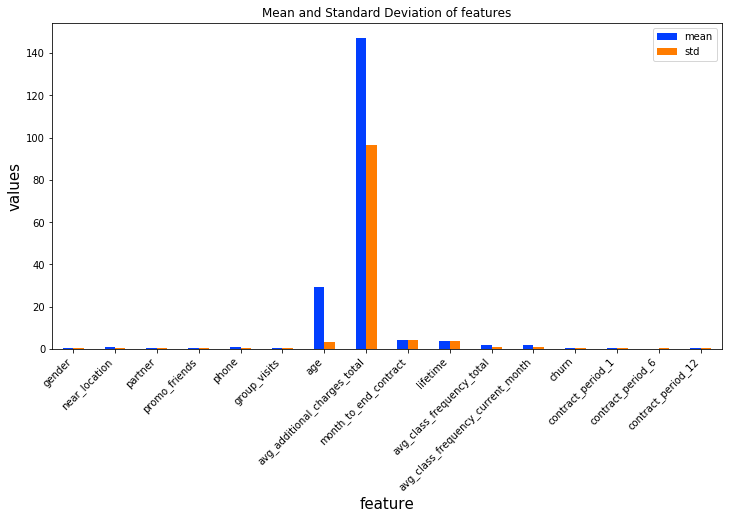

```python
gym_data_describe_graph = gym_data_describe[['mean', 'std']].plot(kind = 'bar', figsize = (12, 6))
plt.title('Mean and Standard Deviation of features')
gym_data_describe_graph.set_xticklabels(gym_data_describe['feature'], rotation = 45, ha = 'right')
plt.xlabel('feature', size = 15)
plt.ylabel('values', size = 15)
plt.show()
```

*2.b Conclusion*

- When comparing the mean to the median - some features have outliers
- The standard deviation of the features differ from each other
- the features need to be scaled - this is done via standardization which will make the distribution have a mean of 0 and a standard deviation of 1

*2.c Use the groupby() method to look at the mean features values in two groups: those who left (churn) and those who stayed*

```python
churned_avg = gym_data.groupby(['churn']).mean().T.reset_index()
churned_avg = churned_avg.rename(columns = {'index': 'feature', 0: 'active', 1: 'churned'})
churned_avg
```

| churn | feature | active | churned |
| --- | --- | --- | --- |
| 0 | gender | 0.510037 | 0.510839 |
| 1 | near_location | 0.873086 | 0.768143 |
| 2 | partner | 0.534195 | 0.355325 |
| 3 | promo_friends | 0.353522 | 0.183789 |
| 4 | phone | 0.903709 | 0.902922 |
| 5 | group_visits | 0.464103 | 0.268615 |
| 6 | age | 29.976523 | 26.989632 |
| 7 | avg_additional_charges_total | 158.445715 | 115.082899 |
| 8 | month_to_end_contract | 5.283089 | 1.662582 |
| 9 | lifetime | 4.711807 | 0.990575 |
| 10 | avg_class_frequency_total | 2.024876 | 1.474995 |
| 11 | avg_class_frequency_current_month | 2.027882 | 1.044546 |
| 12 | contract_period_1 | 0.433141 | 0.880302 |
| 13 | contract_period_6 | 0.248044 | 0.098021 |
| 14 | contract_period_12 | 0.318816 | 0.021678 |

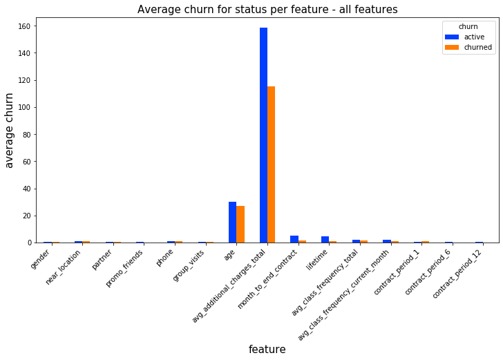

```python
# plot a graph of all feature averages
churned_avg_graph = churned_avg.plot(kind = 'bar', figsize = (12, 6))
plt.title('Average churn for status per feature - all features', size = 15)
churned_avg_graph.set_xticklabels(churned_avg['feature'], rotation = 45, ha = 'right')
plt.xlabel('feature', size = 15)
plt.ylabel('average churn', size = 15)
plt.show()
```

```python
# zoom in on features with lower mean values
churned_avg_low_values = churned_avg.drop([6, 7])
churned_avg_low_values
```

| churn | feature | active | churned |
| --- | --- | --- | --- |
| 0 | gender | 0.510037 | 0.510839 |
| 1 | near_location | 0.873086 | 0.768143 |
| 2 | partner | 0.534195 | 0.355325 |
| 3 | promo_friends | 0.353522 | 0.183789 |
| 4 | phone | 0.903709 | 0.902922 |
| 5 | group_visits | 0.464103 | 0.268615 |
| 8 | month_to_end_contract | 5.283089 | 1.662582 |
| 9 | lifetime | 4.711807 | 0.990575 |
| 10 | avg_class_frequency_total | 2.024876 | 1.474995 |
| 11 | avg_class_frequency_current_month | 2.027882 | 1.044546 |
| 12 | contract_period_1 | 0.433141 | 0.880302 |
| 13 | contract_period_6 | 0.248044 | 0.098021 |
| 14 | contract_period_12 | 0.318816 | 0.021678 |

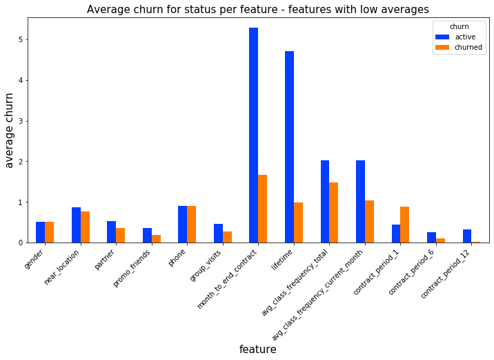

```python
# plot a graph of the features with low average values
churned_avg_low_values_graph = churned_avg_low_values.plot(kind = 'bar', figsize = (12, 6))
plt.title('Average churn for status per feature - features with low averages', size = 15)
churned_avg_low_values_graph.set_xticklabels(churned_avg_low_values['feature'], rotation = 45, ha = 'right')
plt.xlabel('feature', size = 15)
plt.ylabel('average churn', size = 15)
plt.show()
```

*2.c Conclusion*

Based on the average values of features for clients that are active vs churned:

On average:

- status is equal based on gender
- there are more active clients near a gym
- there are more active clients when they are an employee of a parnter company
- there are more active clients when they get a promo code from a friend
- status is equal based on providing a phone number
- there are more active clients who attend group classes
- active clients are older than churned clients
- active clients spend more on additonal services
- active clients currently have a longer contract period
- active clients have been going to the gym longer
- active clients go to more classes
- active clients currently go to more classes
- there are more churned clients with a 1 month contract
- there are more active clients with a 6 month contract
- there are more active clients with a 12 month contract

*2.d Plot bar histograms and feature distributions for those who left (churn) and those who stayed*

*Create queries of active vs churned clients*

```python
gym_data['churn'].value_counts(dropna = True)
```

```
0    2939
1    1061
Name: churn, dtype: int64
```

```python
# query active clients i.e. churn == 0 == False
gym_data_active = gym_data.query('churn == 0')
gym_data_active['churn'].value_counts(dropna = True)
```

```
0    2939
Name: churn, dtype: int64
```

```python
# query churned clients i.e. churn == 1 == True
gym_data_churned = gym_data.query('churn == 1')
gym_data_churned['churn'].value_counts(dropna = True)
```

```
1    1061
Name: churn, dtype: int64
```

*Create a function for plotting histograms of numerical data*

```python
def plot_a_histogram(column):
    plt.figure(figsize = (12, 6))
#     plt.hist(gym_data_active[column], label = 'active', alpha = 0.7)
#     plt.hist(gym_data_churned[column], label = 'churned', alpha = 0.7)
    sns.distplot(gym_data_active[column], label = 'active')
    sns.distplot(gym_data_churned[column], label = 'churned')
    plt.title('{} distribution'.format(column), size = 15)
    plt.xlabel('{}'.format(column), size = 15)
#     plt.ylabel('number of clients', size = 15) # use with plt.hist()
    plt.ylabel('frequency', size = 15) # use with sns.distplot()
    plt.legend()
    plt.show()
```

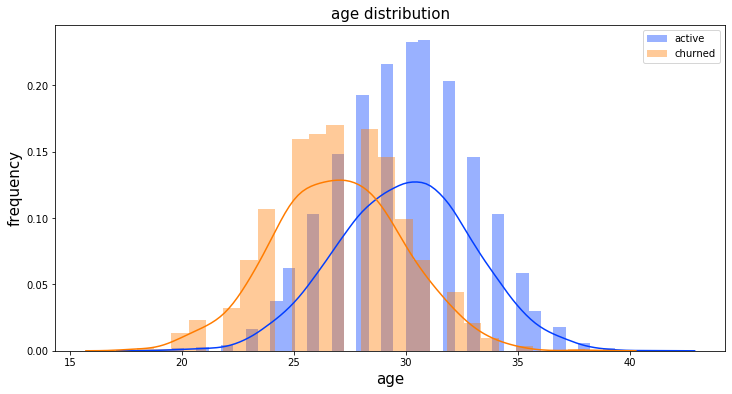

```python
plot_a_histogram('age')
```

- The majority of active clients are between the ages 25-35
- The majoirty of churned clients are between the ages 24-30

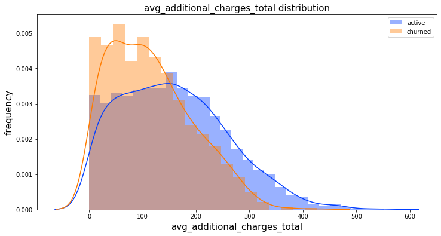

```python
plot_a_histogram('avg_additional_charges_total')
```

- Most active clients spend between 0 - 350 dollars
- Most churned clients spent between 0 - 250 dollars

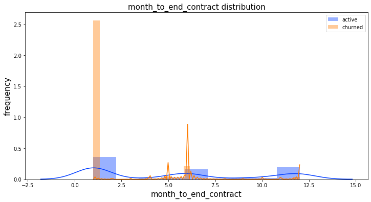

```python
plot_a_histogram('month_to_end_contract')
```

- Most churned clients had a 1 month contract and/or 1 month left of their contract
- About half of active clients have 1 month left of their contract, this may indidicate that they are the most likely to leave next
- The other half of active clients have 6 or 12 months left on their contracts

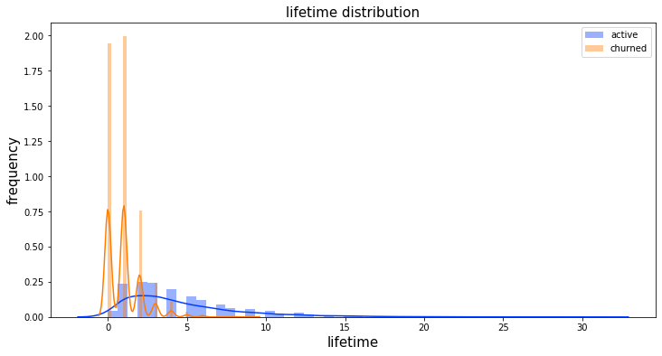

```python
plot_a_histogram('lifetime')
```

- Most churned clients maintained a contract for 3 months or less
- Most active clients maintained a contract for 8 months or less

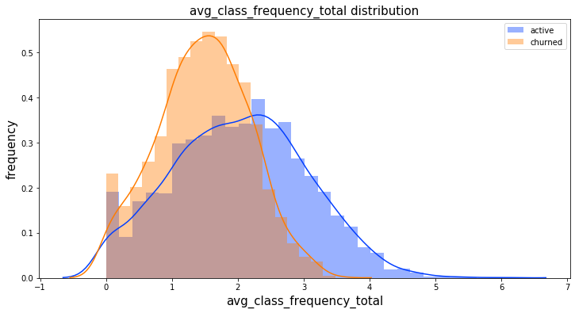

```python
plot_a_histogram('avg_class_frequency_total')
```

- Most churned clients visited the gym on average 1 - 2 days per week during their entire contract lifetime
- Most active clients visit the gym on average 1 - 3 days per week during their entire contract lifetime

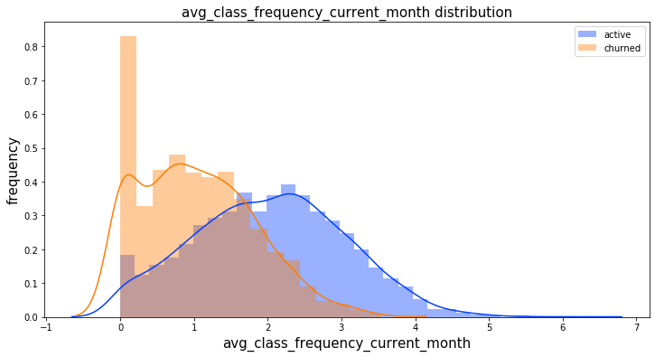

```python
plot_a_histogram('avg_class_frequency_current_month')
```

- For the current month most churned clients visited the gym on average 0 - 2 days per week
- For the current month, most active clients visited the gym on average 0 - 4 days per week

*Create a function for plotting categorical data*

```python
gym_data.head(2)
```

|  | gender | near_location | partner | promo_friends | phone | group_visits | age | avg_additional_charges_total | month_to_end_contract | lifetime | avg_class_frequency_total | avg_class_frequency_current_month | churn | contract_period_1 | contract_period_6 | contract_period_12 |
| --- | --- | --- | --- | --- | --- | --- | --- | --- | --- | --- | --- | --- | --- | --- | --- | --- |
| 0 | 1 | 1 | 1 | 1 | 0 | 1 | 29 | 14.227470 | 5.0 | 3 | 0.020398 | 0.000000 | 0 | 0 | 1 | 0 |
| 1 | 0 | 1 | 0 | 0 | 1 | 1 | 31 | 113.202938 | 12.0 | 7 | 1.922936 | 1.910244 | 0 | 0 | 0 | 1 |

```python
def plot_a_bargraph(column, xticks = ['False', 'True']):
    table = gym_data.pivot_table(index = column, columns = 'churn', values = 'age', aggfunc = 'count')
    graph = table.plot(kind = 'bar')
    plt.title('{} feature status distribution'.format(column), size = 15)
    graph.set_xticklabels(xticks, rotation = 0)
    plt.xlabel('{}'.format(column), size = 15)
    plt.ylabel('number of clients', size = 15)
    plt.legend(['active', 'churned'])
    plt.show()
```

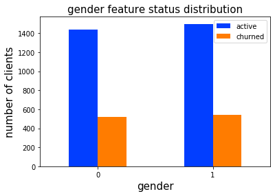

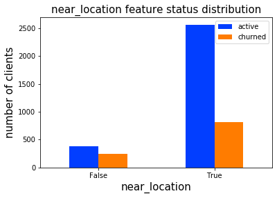

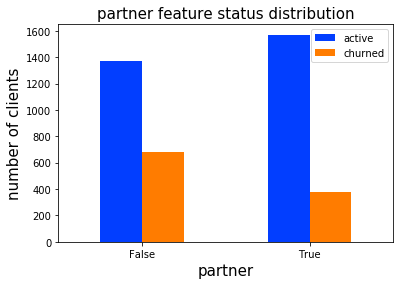

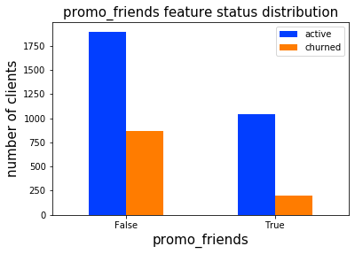

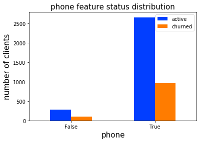

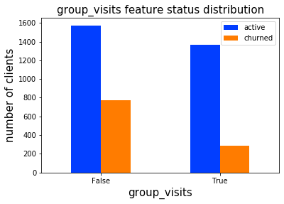

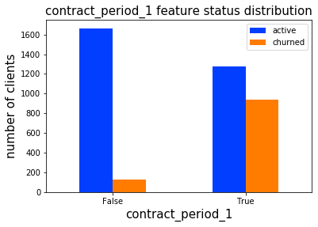

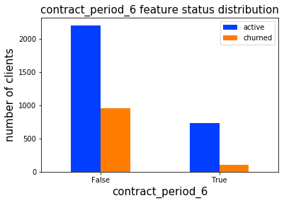

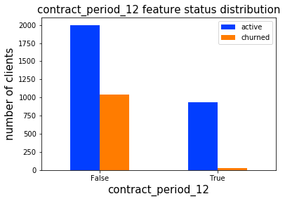

```python
plot_a_bargraph('gender', xticks = [0, 1])
plot_a_bargraph('near_location')
plot_a_bargraph('partner')
plot_a_bargraph('promo_friends')
plot_a_bargraph('phone')
plot_a_bargraph('group_visits')
plot_a_bargraph('contract_period_1')
plot_a_bargraph('contract_period_6')
plot_a_bargraph('contract_period_12')
```

**Reviewer's comment** Very good! You studied feature distributions in the two groups and made some interesting observations!

*2.e Build a correlation matrix and display it*

```python
gym_correlation_matrix = gym_data.corr()
```

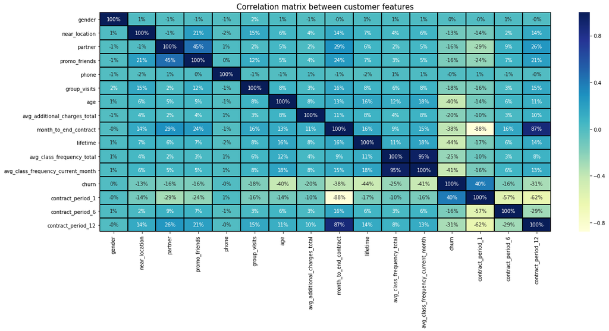

```python
plt.figure(figsize = (20, 8))
plt.title('Correlation matrix between customer features', size = 15)

sns.heatmap(gym_correlation_matrix,
            annot= True,
            fmt = '.0%',
            linewidths = 1,
            linecolor = 'black',
            cmap = 'YlGnBu',
            yticklabels = True,
           )
# ax.set_ylabel('Features', fontsize=14)
# ax.set_xlabel('Features', fontsize=14)
plt.show()
```

*2.e Conclusion*

Strong positive correlations 80% or more:

- month_to_end_contrac and contrac_period_12
- avg_class_frequency_total and avg_class_frequencey_current_month

Positive correlations 40% - 80%:

- partner and promo_friends
- churn and contrac_period_1

Strong negative correlations -80% or less:

- month_to_end_contract and contrac_period_1

Negative correlations -40% - -80%:

- churn and age
- churn and lifetime
- churn and avg_class_frequencey_current_month
- churn and month_to_end contract (-38%)
- special note: not including the contract periods compared to each other because this makes sense, if you have one contract, you dont have the other

**Reviewer's comment** Correlations were studied successfully!

# Step 2 Conclusion - Carry out exploratory data analysis (EDA)

**Reviewer's comment** Ok!

# Step 3 Build a model to predict user churn

*Goal*

- Build a binary classification model for customers where the target feature is the user's leaving next month.

*Plan of Action*

*Logistic Regression data prep*

*Remove featues with multicolinearity - must be done by hand for Logistic Regression models*

- Test two versions
  - Version 1: Remove the following three features:
    - avg_class_frequency_total, this leaves avg_class_frequency_total_current_month
    - contract_period_1 and contract_period_12, this leaves month_to_end_contract
  - Version 2: Remove the following two features:
    - avg_class_frequency_total, this leaves avg_class_frequency_total_current_month
    - month_to_end_contract, this leaves contract_period_1 and contract_period_12

```python
# version 1 remove 3 features
gym_data_lr_v1 = gym_data.drop(['avg_class_frequency_total', 'contract_period_1', 'contract_period_12'], axis = 1)
gym_data_lr_v1.columns
```

```
Index(['gender', 'near_location', 'partner', 'promo_friends', 'phone',
       'group_visits', 'age', 'avg_additional_charges_total',
       'month_to_end_contract', 'lifetime',
       'avg_class_frequency_current_month', 'churn', 'contract_period_6'],
      dtype='object')
```

```python
# version 1 remove 2 features
gym_data_lr_v2 = gym_data.drop(['avg_class_frequency_total', 'month_to_end_contract'], axis = 1)
gym_data_lr_v2.columns
```

```
Index(['gender', 'near_location', 'partner', 'promo_friends', 'phone',
       'group_visits', 'age', 'avg_additional_charges_total', 'lifetime',
       'avg_class_frequency_current_month', 'churn', 'contract_period_1',
       'contract_period_6', 'contract_period_12'],
      dtype='object')
```

**Reviewer's comment** It's nice that you dealt with the multicollinearity problem

*Divide the data into features (the X matrix) and a target variable (y)*

```python
# X matrix Logistic Regression V1
X_lr_v1 = gym_data_lr_v1.drop('churn', axis = 1)

# target variable Logistic Regression V1
y_lr_v1 = gym_data_lr_v1['churn']

# ----------------------------------------------
# X matrix Logistic Regression V2
X_lr_v2 = gym_data_lr_v2.drop('churn', axis = 1)

# target variable Logistic Regression V2
y_lr_v2 = gym_data_lr_v2['churn']

# ----------------------------------------------
# X matrix Random Forest
X = gym_data.drop('churn', axis = 1)

# target variable Random Forest
y = gym_data['churn']
```

*3.a Divide the data into train and validation sets using the train_test_split() function*

```python
# Logistic Regression V1
X_train_lr_v1, X_test_lr_v1, y_train_lr_v1, y_test_lr_v1 = train_test_split(X_lr_v1, y_lr_v1, test_size = 0.2, random_state = 0)

# Logistic Regression V1
X_train_lr_v2, X_test_lr_v2, y_train_lr_v2, y_test_lr_v2 = train_test_split(X_lr_v2, y_lr_v2, test_size = 0.2, random_state = 0)

# Random Forest
X_train_rf, X_test_rf, y_train_rf, y_test_rf = train_test_split(X, y, test_size = 0.2, random_state = 0)
```

*3.b Train the model on the train set with two methods*

&

*3.c Evaluate accuracy, precision, and recall for both models using the validation data. Use them to compare the models*

*3.b.1 Logistic Regression Model*

```python
# define the model's algorithm
model_lr_v1 = LogisticRegression()

# train the model
model_lr_v1.fit(X_train_lr_v1, y_train_lr_v1)

# use the trained model to make a forcast
pred_lr_v1 = model_lr_v1.predict(X_test_lr_v1)
```

```python
# define the model's algorithm
model_lr_v2 = LogisticRegression()

# train the model
model_lr_v2.fit(X_train_lr_v2, y_train_lr_v2)

# use the trained model to make a forcast
pred_lr_v2 = model_lr_v2.predict(X_test_lr_v2)
```

*3.c.1 Logistic Regression Stats*

```python
print('Logistic Regression Model Stats V1 (3 features removed)')
print('Accuracy: {:.2f}'.format(accuracy_score(y_test_lr_v1, pred_lr_v1)))
print('Precision: {:.2f}'.format(precision_score(y_test_lr_v1, pred_lr_v1)))
print('Recall: {:.2f}'.format(recall_score(y_test_lr_v1, pred_lr_v1)))
```

```
Logistic Regression Model Stats V1 (3 features removed)
Accuracy: 0.90
Precision: 0.80
Recall: 0.79
```

```python
print('Logistic Regression Model Stats V2 (2 features removed)')
print('Accuracy: {:.2f}'.format(accuracy_score(y_test_lr_v2, pred_lr_v2)))
print('Precision: {:.2f}'.format(precision_score(y_test_lr_v2, pred_lr_v2)))
print('Recall: {:.2f}'.format(recall_score(y_test_lr_v2, pred_lr_v2)))
```

```
Logistic Regression Model Stats V2 (2 features removed)
Accuracy: 0.90
Precision: 0.79
Recall: 0.80
```

*3.b.2 Random Forest Model*

```python
# define the model's algorithm
model_rf = RandomForestClassifier(n_estimators = 100, max_features = 9, random_state = 0)

# train the model
model_rf.fit(X_train_rf, y_train_rf)

# use the trained model to make a forcast
pred_rf = model_rf.predict(X_test_rf)
```

*3.c.2 Random Forest Stats*

```python
print('Random Forest Classifier Model Stats:')
print('Accuracy: {:.2f}'.format(accuracy_score(y_test_rf, pred_rf)))
print('Precision: {:.2f}'.format(precision_score(y_test_rf, pred_rf)))
print('Recall: {:.2f}'.format(recall_score(y_test_rf, pred_rf)))
```

```
Random Forest Classifier Model Stats:
Accuracy: 0.93
Precision: 0.85
Recall: 0.85
```

# Step 3 Conclusion - Build a model to predict user churn

*Actions Performed*

- Data was prepared for logistic regression
  - Features with multicolinearity were removed by hand
    - Two versions were created to see the affects of removal
    - V1 removed 3 features: avg_class_frequency_total, contract_period_1, contract_period_12
    - V2 removed 2 features: avg_class_frequency_total, month_to_end_contract
  - Random Forest models are not affected my mulitcolinearity
- Data was divided in to matrices and target variables for logistic regression V1 & V2 and Random Forest
- 3.a Data was divided into train and validation sets using the train_test_split() function
- 3.b The models (logistic regression V1 & V2 and Random Forest) were trained on the train sets
- 3.c The accuracy, precision, and recall were calculated and used to compare models
  - Logistic Regression V1 Stats (3 features removed)
    - Accuracy: 0.90
    - Precision: 0.80
    - Recall: 0.79
  - Logistic Regression V2 Stats (2 features removed)
    - Accuracy: 0.90
    - Precision: 0.79
    - Recall: 0.80
  - Random Forest Stats
    - Accuracy: 0.93
    - Precision: 0.85
    - Recall: 0.85
  - *The Random Forest Model fits the best*
    - It has the the highest accuracy, precision, and reacall
- Accuracy: share of accurate predictions among all predictions - works best when the classes are balanced i.e. the objects are distributed almost evenly between the classes (50/50)
  - closer to 100% the better
- Precision: share of predictions in class 1 are true i.e. the correct answers only in the target class
  - closer to 1 the better
- Recall: the number of real calls 1 objects discovered in the model
  - colser to 1 the better

**Reviewer's comment** The models were trained and evaluated correctly. Conclusions look good.

# Step 4 Create User Clusters

*Plan of Action*

*4.a Standarize the data.*

```python
# create a StandarScaler object
scaler = StandardScaler()

# train the scaler and transform the matrix for the train set
X_scaler = scaler.fit_transform(X)
```

*4.b Use the linkage() function to build a matrix of distances based on the standardized feature matrix and plot a dendrogram. Note: rendering the dendrogram may take time! Use the resulting graph to estimate the number of clusters you can single out.*

```python
# create links
linked = linkage(X_scaler, method = 'ward')
```

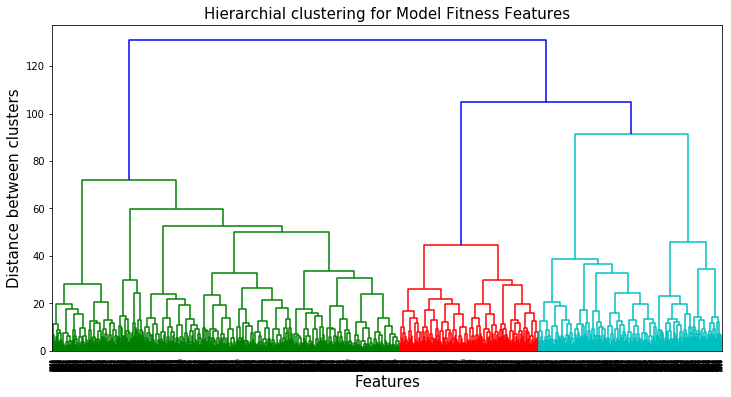

```python
# plot the dendogram
plt.figure(figsize=(12, 6))
dendrogram(linked, orientation='top')
plt.title('Hierarchial clustering for Model Fitness Features', size = 15)
plt.xlabel('Features', size = 15)
plt.ylabel('Distance between clusters', size = 15)
plt.show()
```

*4.c Train the clustering model with the K-means algorithm and predict customer clusters. Number of clusters n = 5*

```python
# group objects step by step. K-mean is used when number of clusters is already known: n = 5
km = KMeans(n_clusters = 5)

# apply the algorithm to the data and store the indices of the clusters suggested by the algorithm
labels = km.fit_predict(X_scaler)
```

```python
# add the calculated clusters to the data
gym_data['cluster'] = labels
gym_data.head()
```

|  | gender | near_location | partner | promo_friends | phone | group_visits | age | avg_additional_charges_total | month_to_end_contract | lifetime | avg_class_frequency_total | avg_class_frequency_current_month | churn | contract_period_1 | contract_period_6 | contract_period_12 | cluster |
| --- | --- | --- | --- | --- | --- | --- | --- | --- | --- | --- | --- | --- | --- | --- | --- | --- | --- |
| 0 | 1 | 1 | 1 | 1 | 0 | 1 | 29 | 14.227470 | 5.0 | 3 | 0.020398 | 0.000000 | 0 | 0 | 1 | 0 | 1 |
| 1 | 0 | 1 | 0 | 0 | 1 | 1 | 31 | 113.202938 | 12.0 | 7 | 1.922936 | 1.910244 | 0 | 0 | 0 | 1 | 0 |
| 2 | 0 | 1 | 1 | 0 | 1 | 0 | 28 | 129.448479 | 1.0 | 2 | 1.859098 | 1.736502 | 0 | 1 | 0 | 0 | 2 |
| 3 | 0 | 1 | 1 | 1 | 1 | 1 | 33 | 62.669863 | 12.0 | 2 | 3.205633 | 3.357215 | 0 | 0 | 0 | 1 | 0 |
| 4 | 1 | 1 | 1 | 1 | 1 | 0 | 26 | 198.362265 | 1.0 | 3 | 1.113884 | 1.120078 | 0 | 1 | 0 | 0 | 2 |

*4.d Look at the mean feature values for clusters. Does anything catch your eye?*

```python
# calculate the feature averages for each cluster
cluster_avg = gym_data.groupby(['cluster']).mean().T.reset_index()
# rename feature column
cluster_avg = cluster_avg.rename(columns = {'index': 'feature'})
# show results
cluster_avg
```

| cluster | feature | 0 | 1 | 2 | 3 | 4 |
| --- | --- | --- | --- | --- | --- | --- |
| 0 | gender | 0.508333 | 0.516827 | 0.476099 | 0.552055 | 0.513889 |
| 1 | near_location | 0.932292 | 0.861779 | 1.000000 | 0.990411 | 0.000000 |
| 2 | partner | 0.715625 | 0.575721 | 0.333652 | 0.338356 | 0.428241 |
| 3 | promo_friends | 0.477083 | 0.375000 | 0.220841 | 0.276712 | 0.071759 |
| 4 | phone | 0.903125 | 0.895433 | 0.909178 | 0.902740 | 0.907407 |
| 5 | group_visits | 0.544792 | 0.442308 | 0.317400 | 0.469863 | 0.192130 |
| 6 | age | 29.816667 | 29.544471 | 27.978967 | 30.156164 | 28.361111 |
| 7 | avg_additional_charges_total | 163.589978 | 151.379994 | 126.142654 | 159.425708 | 130.681467 |
| 8 | month_to_end_contract | 10.839583 | 5.617788 | 1.000000 | 1.004110 | 1.000000 |
| 9 | lifetime | 4.664583 | 4.137019 | 2.140535 | 4.975342 | 2.564815 |
| 10 | avg_class_frequency_total | 2.014054 | 1.941094 | 1.253095 | 2.649781 | 1.672497 |
| 11 | avg_class_frequency_current_month | 2.007001 | 1.887587 | 0.976004 | 2.635555 | 1.449441 |
| 12 | churn | 0.023958 | 0.125000 | 0.609943 | 0.097260 | 0.520833 |
| 13 | contract_period_1 | 0.000000 | 0.000000 | 1.000000 | 0.998630 | 1.000000 |
| 14 | contract_period_6 | 0.000000 | 1.000000 | 0.000000 | 0.001370 | 0.000000 |
| 15 | contract_period_12 | 1.000000 | 0.000000 | 0.000000 | 0.000000 | 0.000000 |

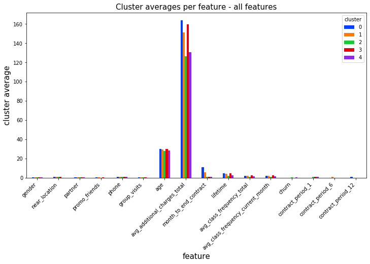

```python
# plot a bar graph of all feature averages for each cluster
cluster_avg_graph = cluster_avg.plot(kind = 'bar', figsize = (12, 6))
plt.title('Cluster averages per feature - all features', size = 15)
cluster_avg_graph.set_xticklabels(cluster_avg['feature'], rotation = 45, ha = 'right')
plt.xlabel('feature', size = 15)
plt.ylabel('cluster average', size = 15)
plt.show()
```

```python
# zoom in on features with lower average values
cluster_avg_low_values = cluster_avg.drop([6, 7])
cluster_avg_low_values
```

| cluster | feature | 0 | 1 | 2 | 3 | 4 |
| --- | --- | --- | --- | --- | --- | --- |
| 0 | gender | 0.508333 | 0.516827 | 0.476099 | 0.552055 | 0.513889 |
| 1 | near_location | 0.932292 | 0.861779 | 1.000000 | 0.990411 | 0.000000 |
| 2 | partner | 0.715625 | 0.575721 | 0.333652 | 0.338356 | 0.428241 |
| 3 | promo_friends | 0.477083 | 0.375000 | 0.220841 | 0.276712 | 0.071759 |
| 4 | phone | 0.903125 | 0.895433 | 0.909178 | 0.902740 | 0.907407 |
| 5 | group_visits | 0.544792 | 0.442308 | 0.317400 | 0.469863 | 0.192130 |
| 8 | month_to_end_contract | 10.839583 | 5.617788 | 1.000000 | 1.004110 | 1.000000 |
| 9 | lifetime | 4.664583 | 4.137019 | 2.140535 | 4.975342 | 2.564815 |
| 10 | avg_class_frequency_total | 2.014054 | 1.941094 | 1.253095 | 2.649781 | 1.672497 |
| 11 | avg_class_frequency_current_month | 2.007001 | 1.887587 | 0.976004 | 2.635555 | 1.449441 |
| 12 | churn | 0.023958 | 0.125000 | 0.609943 | 0.097260 | 0.520833 |
| 13 | contract_period_1 | 0.000000 | 0.000000 | 1.000000 | 0.998630 | 1.000000 |
| 14 | contract_period_6 | 0.000000 | 1.000000 | 0.000000 | 0.001370 | 0.000000 |
| 15 | contract_period_12 | 1.000000 | 0.000000 | 0.000000 | 0.000000 | 0.000000 |

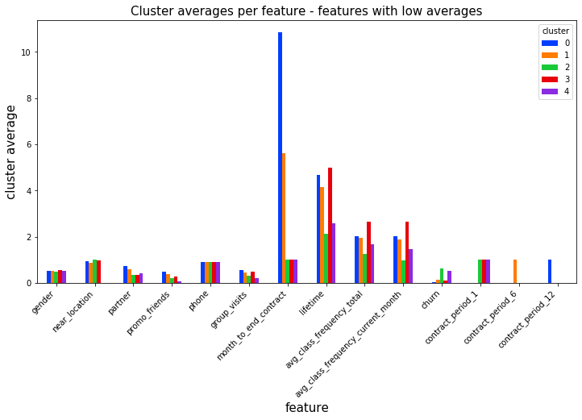

```python
# plot a bar graph of features with low averages for each cluster
cluster_avg_low_values_graph = cluster_avg_low_values.plot(kind = 'bar', figsize = (12, 6))
plt.title('Cluster averages per feature - features with low averages', size = 15)
cluster_avg_low_values_graph.set_xticklabels(cluster_avg_low_values['feature'], rotation = 45, ha = 'right')
plt.xlabel('feature', size = 15)
plt.ylabel('cluster average', size = 15)
plt.show()
```

*4.e Plot distributions of features for the clusters. Do you notice anything?*

*Create a data table for categorical features by cluster*

```python
# create a table that counts the number of clients by status and displays them via cluster
cat_cluster_table = gym_data.pivot_table(index = 'churn', values = ('gender',
                                                            'near_location',
                                                            'partner',
                                                            'promo_friends',
                                                            'phone',
                                                            'group_visits',
                                                            'contract_period_1',
                                                            'contract_period_6',
                                                            'contract_period_12'),
                                 columns = 'cluster',
                                  aggfunc = 'sum')
cat_cluster_table.reset_index()
```

| cluster | churn | contract_period_1 0 | contract_period_1 1 | contract_period_1 2 | contract_period_1 3 | contract_period_1 4 | contract_period_12 0 | contract_period_12 1 | contract_period_12 2 | contract_period_12 3 | contract_period_12 4 | contract_period_6 0 | contract_period_6 1 | contract_period_6 2 | contract_period_6 3 | contract_period_6 4 | gender 0 | gender 1 | gender 2 | gender 3 | gender 4 | group_visits 0 | group_visits 1 | group_visits 2 | group_visits 3 | group_visits 4 | near_location 0 | near_location 1 | near_location 2 | … |
| --- | --- | --- | --- | --- | --- | --- | --- | --- | --- | --- | --- | --- | --- | --- | --- | --- | --- | --- | --- | --- | --- | --- | --- | --- | --- | --- | --- | --- | --- | --- |
| 0 | 0 | 0.0 | 0.0 | 408.0 | 658.0 | 207.0 | 937.0 | 0.0 | 0.0 | 0.0 | 0.0 | 0.0 | 728.0 | 0.0 | 1.0 | 0.0 | 476 | 372 | 185 | 361 | 105 | 515 | 337 | 155 | 314 | 43 | 875 | 631 | 408 | … |
| 1 | 1 | 0.0 | 0.0 | 638.0 | 71.0 | 225.0 | 23.0 | 0.0 | 0.0 | 0.0 | 0.0 | 0.0 | 104.0 | 0.0 | 0.0 | 0.0 | 12 | 58 | 313 | 42 | 117 | 8 | 31 | 177 | 29 | 40 | 20 | 86 | 638 | … |

*Create a function to plot categorical featues*

```python
# create a function to plot the categorical data
def cat_data_bar_plot(column):
    graph = cat_cluster_table[column].plot(kind = 'bar')
    graph.set_xticklabels(['active', 'churned'], rotation = 0)
    plt.title('{} feature status distibution per cluster'.format(column), size = 15)
    plt.xlabel('client status', size = 15)
    plt.ylabel('number of clients', size = 15)
    plt.show()
```

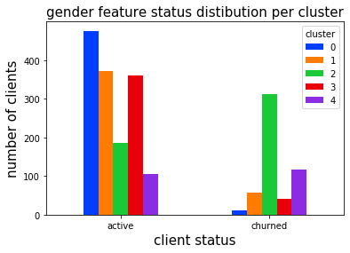

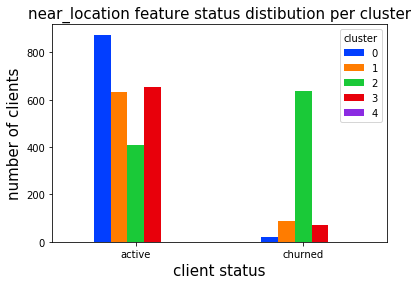

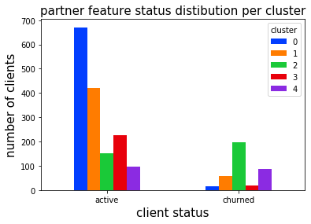

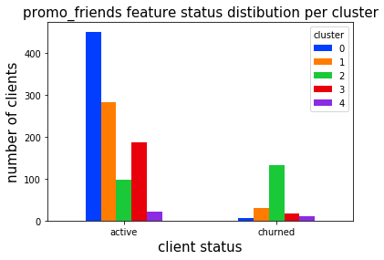

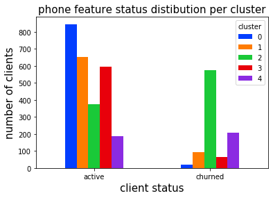

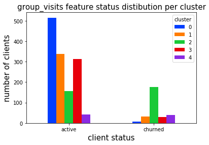

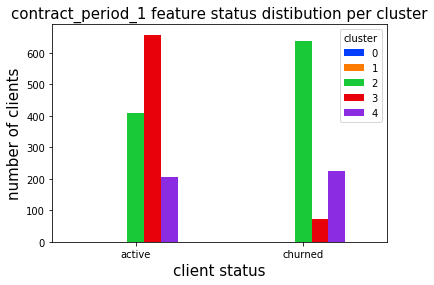

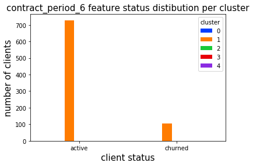

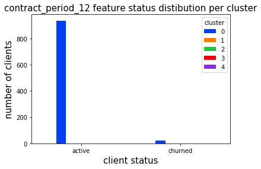

```python
cat_data_bar_plot('gender')
cat_data_bar_plot('near_location')
cat_data_bar_plot('partner')
cat_data_bar_plot('promo_friends')
cat_data_bar_plot('phone')
cat_data_bar_plot('group_visits')
cat_data_bar_plot('contract_period_1')
cat_data_bar_plot('contract_period_6')
cat_data_bar_plot('contract_period_12')
```